# Notebook

Notebook for exploring and plotting **RAW ISMIP6 *nc data**.  
by Praveen Kumar and Sophie Nowicki.

**Background::**  
This is a notebook that is being created to explore the results from the Experimental protocol for sea level projections from ISMIP6 stand-alone ice sheet models [Nowicki_et_al2020](https://tc.copernicus.org/articles/14/2331/2020/).  
For an overview: Experimental protocol for Antarctic projections refer to the ISMIP6 Wiki  
The data is housed in the University at Buffalo and can be accessed using **Ghub** ([GHUB data-listing](https://theghub.org/dataset-listing)). For this notebook, we will be using ISMIP6 21st Century Antarctic Projections which can be accessed ([Ghub AIS ISMIP6 data](https://theghub.org/resources/4748/about)).  
Please note that data access and downloading is non-trivial. You will need to request data access and have ~2TB of storage space. Details for accessing the data can be found at [How to Access Ghub's Globus endpoints](https://theghub.org/accessing-data-with-globus#endpoints).

**Updates to share with Sophie**

1. Work to refine data access workflow. Is there some one who can point me how to access the data using SSH?
2. Storage and UB account?
3. DATA access should be another notebook.

In this notebook we assume that the user has downloaded the full set of AIS ISMIP6 data

Xplore :: RAW *.nc data files

List the **modelling group** names:

| Index | Model Name |
| --- | --- |
| 0 | .DS_Store |
| 1 | AWI |
| 2 | CPOM |
| 3 | DOE |
| 4 | ILTS_PIK |
| 5 | IMAU |
| 6 | JPL1 |
| 7 | LSCE |
| 8 | NCAR |
| 9 | PIK |
| 10 | UCIJPL |
| 11 | ULB |
| 12 | UTAS |
| 13 | VUB |
| 14 | VUW |

List details of the **ice flow model and experiments** names:

|  | Level_1 | Level_2 | Level_3 | Level_4 | Level_5 | Level_6 | Level_6_Subfolders |
| --- | --- | --- | --- | --- | --- | --- | --- |
| 0 |  | Volumes | Geek_Boi-Ed | ISMIP6 | [/] | None | None |
| 1 |  | Volumes | Geek_Boi-Ed | ISMIP6 | AWI | [/] | None |
| 2 |  | Volumes | Geek_Boi-Ed | ISMIP6 | AWI | PISM1 | [/, ctrl_proj_std, exp01, exp02, exp03, exp04, exp05, exp06, exp07, exp08, exp09, exp10, exp11, exp12, exp13, expA1, expA2, expA3, expA4, expA5, expA6, expA7, expA8, expB1, expB10, expB2, expB3, expB4… |
| 3 |  | Volumes | Geek_Boi-Ed | ISMIP6 | CPOM | [/] | None |
| 4 |  | Volumes | Geek_Boi-Ed | ISMIP6 | CPOM | BISICLES | [/, expT71_08, expT73_08, expTD58_08] |
| 5 |  | Volumes | Geek_Boi-Ed | ISMIP6 | DOE | [/] | None |
| 6 |  | Volumes | Geek_Boi-Ed | ISMIP6 | DOE | MALI | [/, ctrl_proj_std, exp05, exp06, exp07, exp08, exp09, exp10, exp12, exp13] |
| 7 |  | Volumes | Geek_Boi-Ed | ISMIP6 | ILTS_PIK | [/] | None |
| 8 |  | Volumes | Geek_Boi-Ed | ISMIP6 | ILTS_PIK | SICOPOLIS1 | [/, ctrl_proj_std, exp05, exp06, exp07, exp08, exp09, exp10, exp12, exp13, expA5, expA6, expA7, expA8, expB10, expB6, expB7, expB8, expB9, expC1, expC10, expC12, expC3, expC4, expC6, expC7, expC9, exp… |
| 9 |  | Volumes | Geek_Boi-Ed | ISMIP6 | IMAU | [/] | None |
| 10 |  | Volumes | Geek_Boi-Ed | ISMIP6 | IMAU | IMAUICE1 | [/, ctrl_proj_std, exp05, exp06, exp07, exp08, exp09, exp10, exp11, exp12, exp13, hist_std] |
| 11 |  | Volumes | Geek_Boi-Ed | ISMIP6 | IMAU | IMAUICE2 | [/, ctrl_proj_std, exp05, exp06, exp07, exp08, exp09, exp10, exp11, exp12, exp13, expA5, expA6, expA7, expA8, hist_std] |
| 12 |  | Volumes | Geek_Boi-Ed | ISMIP6 | JPL1 | [/] | None |
| 13 |  | Volumes | Geek_Boi-Ed | ISMIP6 | JPL1 | ISSM | [/, abmb, asmb, ctrl, ctrl_proj, exp05, exp06, exp07, exp07_HighPIGL_08, exp07_LowPIGL_08, exp07_PIGL_08, exp08, exp09, exp10, exp12, exp12HighOcean_08, exp12HighPIGL_08, exp12PIGL_08, exp13, expA1, e… |
| 14 |  | Volumes | Geek_Boi-Ed | ISMIP6 | LSCE | [/] | None |
| 15 |  | Volumes | Geek_Boi-Ed | ISMIP6 | LSCE | GRISLI2 | [/, ctrl_proj_std, exp05, exp06, exp07, exp08, exp09, exp10, exp12, exp13, expA5, expA6, expA7, expA8, expB10, expB6, expB7, expB8, expB9, expC1, expC10, expC12, expC3, expC4, expC6, expC7, expC9, exp… |
| 16 |  | Volumes | Geek_Boi-Ed | ISMIP6 | NCAR | [/] | None |
| 17 |  | Volumes | Geek_Boi-Ed | ISMIP6 | NCAR | CISM | [/, ctrl_proj_open, ctrl_proj_std, exp01, exp02, exp03, exp04, exp05, exp06, exp07, exp08, exp09, exp10, exp13, expA1, expA2, expA3, expA4, expA5, expA6, expA7, expA8, expB1, expB10, expB2, expB3, exp… |
| 18 |  | Volumes | Geek_Boi-Ed | ISMIP6 | PIK | [/] | None |
| 19 |  | Volumes | Geek_Boi-Ed | ISMIP6 | PIK | PISM1 | [/, ctrl_proj_open, exp01, exp02, exp03, exp04, hist_open] |
| 20 |  | Volumes | Geek_Boi-Ed | ISMIP6 | PIK | PISM2 | [/, ctrl_proj_open, exp01, exp02, exp03, exp04] |
| 21 |  | Volumes | Geek_Boi-Ed | ISMIP6 | UCIJPL | [/] | None |
| 22 |  | Volumes | Geek_Boi-Ed | ISMIP6 | UCIJPL | ISSM | [/, ctrl_proj_open, ctrl_proj_std, exp01, exp01/exp01_08, exp02, exp02/exp02_08, exp03, exp03/exp03_08, exp04, exp04/exp04_08, exp05, exp05/exp05_08, exp06, exp07, exp08, exp08/exp08_08, exp09, exp09/… |
| 23 |  | Volumes | Geek_Boi-Ed | ISMIP6 | ULB | [/] | None |
| 24 |  | Volumes | Geek_Boi-Ed | ISMIP6 | ULB | fETISh_16km | [/, ctrl_proj_open, ctrl_proj_std, exp01, exp02, exp03, exp04, exp05, exp06, exp07, exp08, exp09, exp10, exp11, exp12, exp13, expA1, expA2, expA3, expA4, expA5, expA6, expA7, expA8, hist_open, hist_st… |
| 25 |  | Volumes | Geek_Boi-Ed | ISMIP6 | ULB | fETISh_32km | [/, ctrl_proj_open, ctrl_proj_std, exp01, exp02, exp03, exp04, exp05, exp06, exp07, exp08, exp09, exp10, exp11, exp12, exp13, expA1, expA2, expA3, expA4, expA5, expA6, expA7, expA8, hist_open, hist_st… |
| 26 |  | Volumes | Geek_Boi-Ed | ISMIP6 | UTAS | [/] | None |
| 27 |  | Volumes | Geek_Boi-Ed | ISMIP6 | UTAS | ElmerIce | [/, ctrl_proj_std, exp05, exp06, exp13] |
| 28 |  | Volumes | Geek_Boi-Ed | ISMIP6 | VUB | [/] | None |
| 29 |  | Volumes | Geek_Boi-Ed | ISMIP6 | VUB | AISMPALEO | [/, ctrl_proj_std, exp05, exp06, exp07, exp08, exp09, exp10, expA5, expA6, expA7, expB6, expB7, expB8, hist_std] |
| 30 |  | Volumes | Geek_Boi-Ed | ISMIP6 | VUW | [/] | None |
| 31 |  | Volumes | Geek_Boi-Ed | ISMIP6 | VUW | PISM | [/, ctrl_proj_open, exp01, exp02, exp03, exp04, hist_open] |

The table above needs to be refined.

1. Make the table generating code to be dynamic based on the folder structure, or include a level for concat in the fun. THis can be engineered differently later

List the variables/data

```
['acabf',
 'base',
 'dlithkdt',
 'iareafl',
 'iareagr',
 'libmassbffl',
 'lim',
 'limnsw',
 'lithk',
 'orog',
 'sftflf',
 'sftgif',
 'sftgrf',
 'strbasemag',
 'tendacabf',
 'tendlibmassbf',
 'topg',
 'xvelbase',
 'xvelmean',
 'xvelsurf',
 'yvelbase',
 'yvelmean',
 'yvelsurf',
 'zvelbase',
 'zvelsurf']
```

Details of the output `data/variable` can be found in in the [ISMIP6-wikki](https://theghub.org/groups/ismip6/wiki/ISMIP6-Projections-Antarctica)

[output not shown]

READ :: ISMIP6 *.nc data files

```
<xarray.Dataset>
Dimensions:  (x: 761, y: 761, time: 86)
Coordinates:

x        (x) float32 -3.04e+06 -3.032e+06 -3.024e+06 ... 3.032e+06 3.04e+06
y        (y) float32 -3.04e+06 -3.032e+06 -3.024e+06 ... 3.032e+06 3.04e+06
time     (time) float32 0.0 365.2 730.5 ... 3.032e+04 3.068e+04 3.105e+04
Data variables:
acabf    (time, y, x) float32 ...
Attributes:
author:       Chen Zhao (Chen.Zhao@utas.edu.au), Rupert Gladstone (Rupert...
Conventions:  CF-1.6
title:        ISMIP6 Projections Greenland model output
institution:  University of Tasmania, Australia
source:       ElmerIce
references:   https://doi.org/10.5194/tc-14-3033-2020
contact:      Name = Chen Zhao,  Rupert Gladstone, Ben Galton-Fenzi , Ema...
comment:      UTAS, ElmerIce
```

```
<xarray.Dataset>
Dimensions:  (x: 761, y: 761, time: 86)
Coordinates:
x        (x) float32 -3.04e+06 -3.032e+06 -3.024e+06 ... 3.032e+06 3.04e+06
y        (y) float32 -3.04e+06 -3.032e+06 -3.024e+06 ... 3.032e+06 3.04e+06
time     (time) float32 0.0 365.2 730.5 ... 3.032e+04 3.068e+04 3.105e+04
Data variables:
acabf    (time, y, x) float32 ...
Attributes:
author:       Chen Zhao (Chen.Zhao@utas.edu.au), Rupert Gladstone (Rupert...
Conventions:  CF-1.6
title:        ISMIP6 Projections Greenland model output
institution:  University of Tasmania, Australia
source:       ElmerIce
references:   https://doi.org/10.5194/tc-14-3033-2020
contact:      Name = Chen Zhao,  Rupert Gladstone, Ben Galton-Fenzi , Ema...
comment:      UTAS, ElmerIce
```

PLOT :: 2D data files

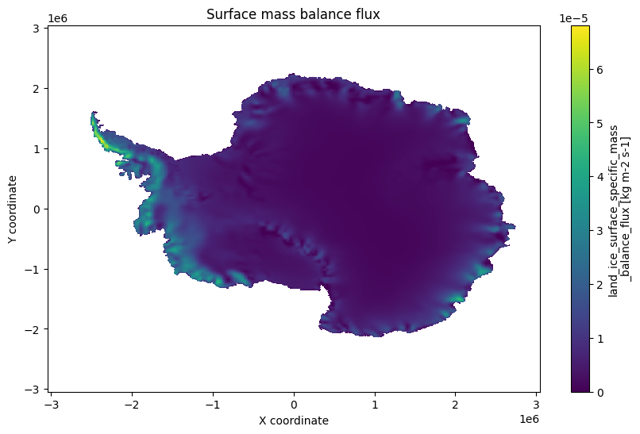

```
<Figure size 1000x600 with 2 Axes>
```